# Stat Eco HW 11 RDA & Variance Decomposition

Kuei Yueh Ko

2017年5月11日

# Set Environment

import needed package

```r
library(ComplexHeatmap)
library(knitr)
library(dplyr)
library(tidyr)
library(vegan)
```

set directories

```r
workdir <- "C:\\Users\\clint\\Documents\\GitHub\\BlogDataAnalysis"
setwd(workdir)

filePathData <- file.path(
    workdir,
    "Data/StatCompEcology/Copepod")
```

# Import data

Read in the copepod data recorded in different stations and preprocess the data to find the dominant species. The final matrix is teh frequency matrix of dominant species in different stations

1. cop_density.txt
   - copepod total density (number/m^3) recorded in each station
2. copepod_composition.txt
   - frequency of each copepod specie recorded in each station.
3. copepodSPlist.txt
   - Species names along the rows of data copepod_composition.txt

**Note: Definition of dominant species:**

- species >=2% of total composition in any cruise-station

```r
# intialize a list to store data
datCPOD <- list()

# read tables: number of copepod in each station
# 34 stations
dat <- read.table(file.path(
    filePathData, "cop_density.txt"),
    header=T)
datCPOD$Density <- dat

# read tables: freq of copepod in each station
# 34 stations x 181 species
dat <- read.table(file.path(
    filePathData, "copepod_composition.txt"),
    header=T)
datCPOD$Compose <- dat

# read tables: species name
# 181 species
dat <- read.table(file.path(
    filePathData, "copepodSPlist.txt"),
    sep="\t", header=F)
datCPOD$SP_Total <- as.character(dat$V1)

# Search for dominant species
dat <- datCPOD$Compose
temp <- apply(dat >= 2, 1, sum)
datCPOD$SP_Dominant <- which(temp > 0)

# Extract the composition of dominant species
dat <- datCPOD$Compose
idx <- datCPOD$SP_Dominant
idn <- datCPOD$SP_Total
dat <- dat[idx,]
rownames(dat) <- idn[idx]

# composition of dominant species
# Note: transform the matrix since
# we are clustering on stations
datCPOD$CompDmt <- t(dat)
datCPOD$CompDmtScale <- scale(t(dat)) # scales the columns of a numeric matrix
#head(datCPOD$CompDmtScale)
```

Visualize the data after preprocess (find the dominant species and scale the result data matrix)

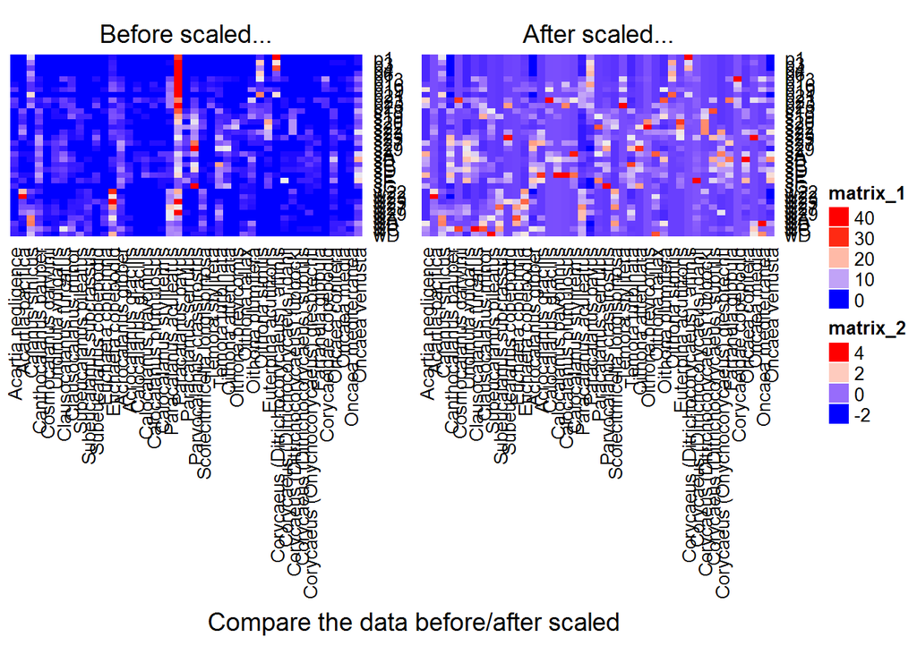

```r
# Original data matrix of dominant species in different stations
dat <- datCPOD$CompDmt
ht1 <- Heatmap(
    dat, column_title = "Before scaled...",
    row_names_gp = gpar(fontsize = 10),
    column_names_max_height=unit(15, "cm"),
    column_names_gp = gpar(fontsize = 10),
    cluster_rows=F, cluster_columns=F)

# Scaled data matrix of dominant species in different stations
dat <- datCPOD$CompDmtScale
ht2 <- Heatmap(
    dat, column_title = "After scaled...",
    row_names_gp = gpar(fontsize = 10),
    column_names_max_height=unit(15, "cm"),
    column_names_gp = gpar(fontsize = 10),
    cluster_rows=F, cluster_columns=F)

# plot
draw(ht1 + ht2,
     column_title = "Compare the data before/after scaled",
     column_title_side = "bottom")
```

import environmental data

```r
datENV <- read.table(file.path(
    filePathData,
    "enviANDdensity.txt"),
    header=T,
    stringsAsFactors = FALSE)
```

# Redundant Analysis (RDA)

Perform RDA analysis  
- Constrained: Rank=11  
- Unconstrained: Rank=22

```r
dat1 <- datCPOD$CompDmtScale
dat2 <- datENV[,-1]
resRDA <- rda(dat1~., dat2)
print(resRDA)
```

```
## Call: rda(formula = dat1 ~ Depth + Temperature + Salinity +
## Fluorescence + DissolvedOxygen + maxT + maxS + maxF + MaxDO +
## FishDensity + CopepodDensity, data = dat2)
##
##               Inertia Proportion Rank
## Total         43.0000     1.0000
## Constrained   23.2705     0.5412   11
## Unconstrained 19.7295     0.4588   22
## Inertia is variance
##
## Eigenvalues for constrained axes:
##  RDA1  RDA2  RDA3  RDA4  RDA5  RDA6  RDA7  RDA8  RDA9 RDA10 RDA11
## 7.567 3.779 3.326 2.076 1.791 1.143 1.082 0.921 0.717 0.587 0.283
##
## Eigenvalues for unconstrained axes:
##   PC1   PC2   PC3   PC4   PC5   PC6   PC7   PC8
## 3.243 2.204 1.912 1.701 1.560 1.378 1.138 1.035
## (Showed only 8 of all 22 unconstrained eigenvalues)
```

WA & LC scores

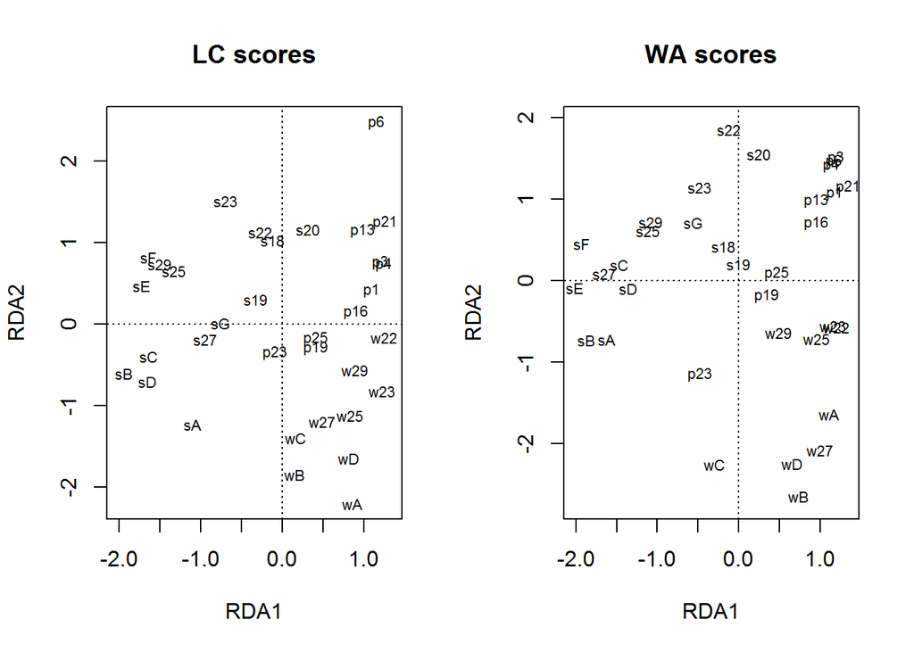

```r
# set plot
par(mfrow=c(1,2))

# plot
plot(resRDA, display="lc", main="LC scores")
plot(resRDA, display="wa", main="WA scores")
```

```r
# reset plot
par(mfrow=c(1,1))
```

If environmental variables correlate with species data, WA and LC scores should resemble each other

```r
spenvcor(resRDA)
```

```
##      RDA1      RDA2      RDA3      RDA4      RDA5      RDA6      RDA7
## 0.9652628 0.8890507 0.8841969 0.8668161 0.8899851 0.7781328 0.7703760
##      RDA8      RDA9     RDA10     RDA11
## 0.8002402 0.8034679 0.6693900 0.7428761
```

It turns out that the correlation is quite high. This can be observed in the plot of WA and LC scores (similar distribution of stations)

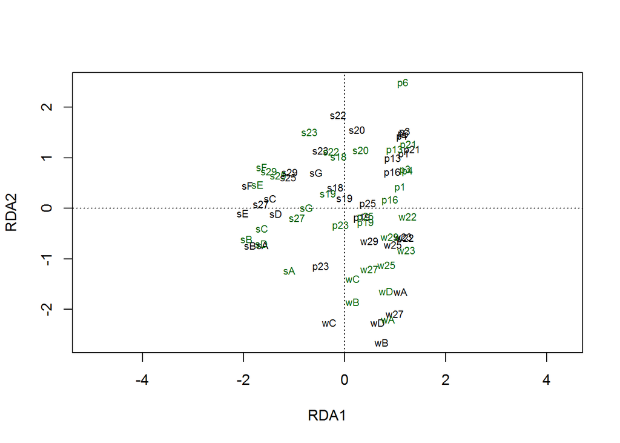

```r
plot(resRDA, dis=c("wa","lc"))
```

```r
#      RDA1      RDA2      RDA3      RDA4
# 0.9652628 0.8890507 0.8841969 0.8668161
```

We can plot the correlation of environment variables and species variables

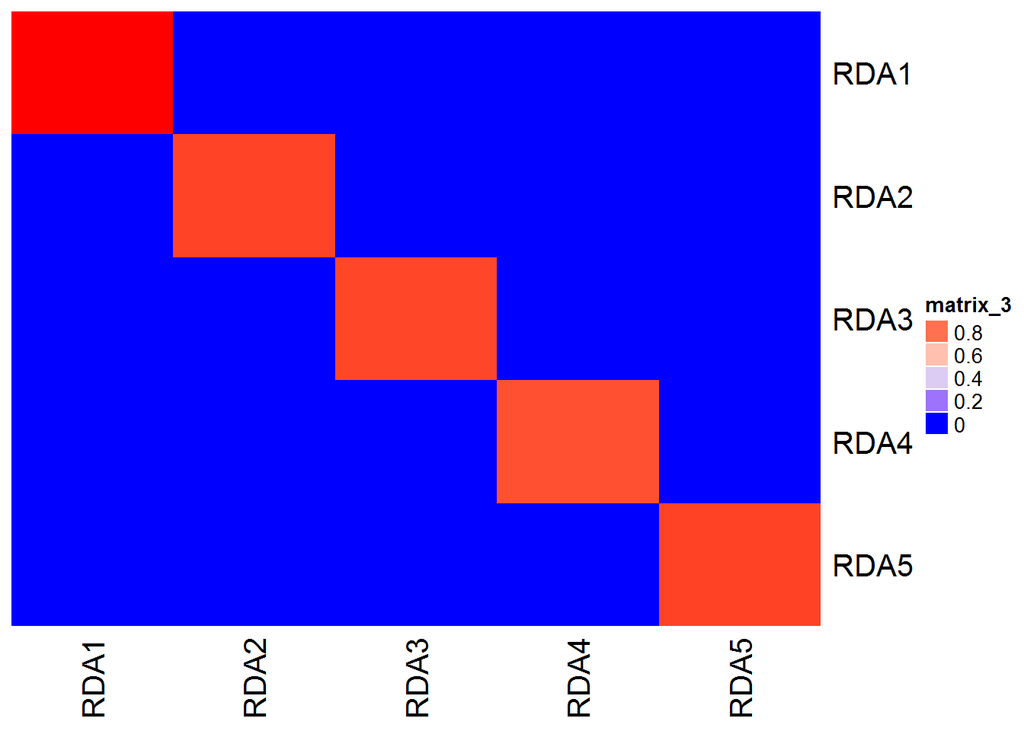

```r
scoreLC <- scores(resRDA, display="lc", choice=c(1:5))
scoreWA <- scores(resRDA, display="wa", choice=c(1:5))
mat <- cor(scoreLC, scoreWA)
Heatmap(
    mat,
    row_names_gp = gpar(fontsize = 15),
    column_names_max_height=unit(15, "cm"),
    column_names_gp = gpar(fontsize = 15),
    cluster_rows=F, cluster_columns=F)
```

biplot using scaling=3

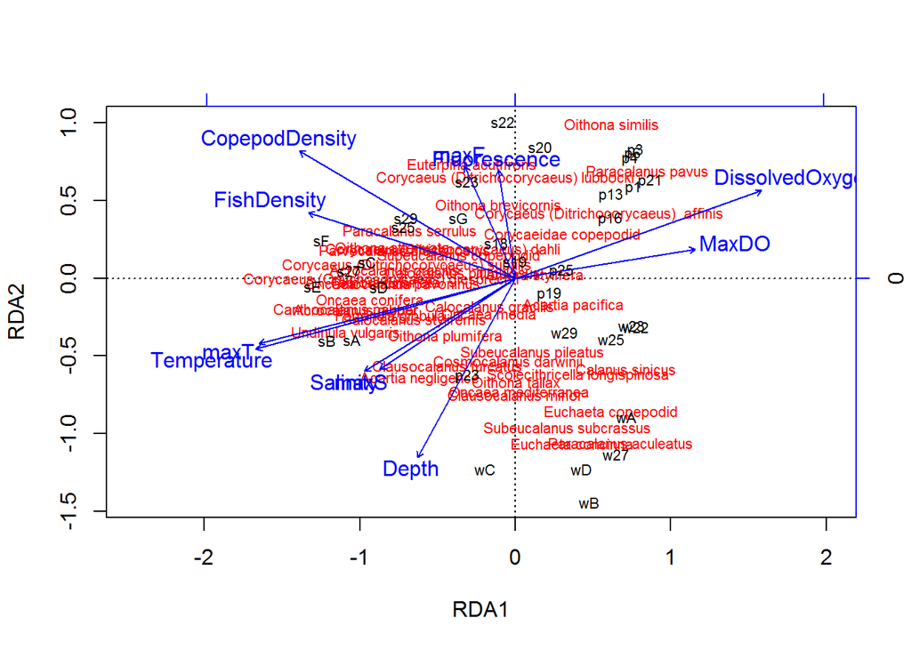

```r
ordiplot(resRDA, type="text", scaling=3)
```

# CCA analysis

```r
dat1 <- datCPOD$CompDmt
dat2 <- datENV[,-1]
resCCA <- cca(dat1~., dat2)
print(resCCA)
```

```
## Call: cca(formula = dat1 ~ Depth + Temperature + Salinity +
## Fluorescence + DissolvedOxygen + maxT + maxS + maxF + MaxDO +
## FishDensity + CopepodDensity, data = dat2)
##
##               Inertia Proportion Rank
## Total          2.6188     1.0000
## Constrained    1.5677     0.5986   11
## Unconstrained  1.0511     0.4014   22
## Inertia is mean squared contingency coefficient
##
## Eigenvalues for constrained axes:
##   CCA1   CCA2   CCA3   CCA4   CCA5   CCA6   CCA7   CCA8   CCA9  CCA10
## 0.5093 0.3480 0.2100 0.1246 0.1179 0.0809 0.0561 0.0460 0.0286 0.0238
##  CCA11
## 0.0224
##
## Eigenvalues for unconstrained axes:
##     CA1     CA2     CA3     CA4     CA5     CA6     CA7     CA8
## 0.21256 0.14306 0.11977 0.08787 0.07055 0.06936 0.05868 0.05048
## (Showed only 8 of all 22 unconstrained eigenvalues)
```

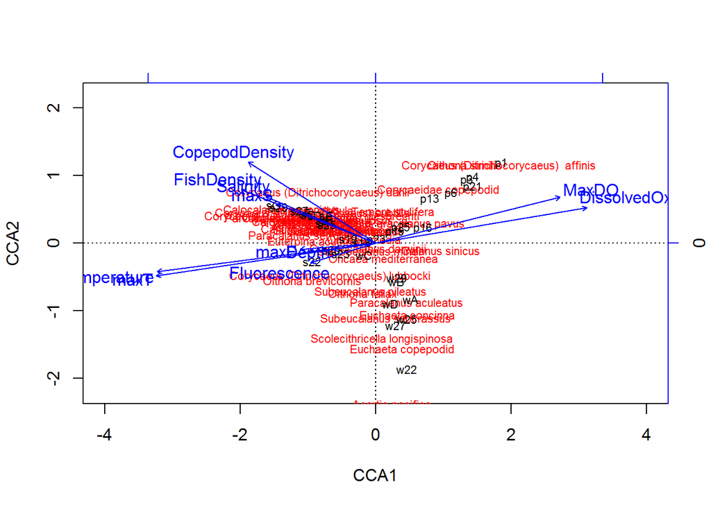

```r
plot(resCCA, scaling=3,
     xlim=c(-4,4),
     ylim=c(-2,2))
```